# DM559/DM545 Assignment 1.2

Part of this script is taken from the very nice tutorial by Peter Norvig: http://nbviewer.jupyter.org/url/norvig.com/ipython/TSP.ipynb

Consider the [Traveling Salesperson Problem](https://en.wikipedia.org/wiki/Travelling_salesman_problem):

> Given a set of cities and the distances between each pair of cities, what is the shortest possible tour that visits each city exactly once, and returns to the starting city?

## Representing an instance of the problem

The only thing that matters about cities is the distance between them. We will ignore the fully general TSP where distances can be defined in any arbitrary way and concentrate on an important special case, the *Euclidean TSP*, where the distance between any two cities is the Euclidean distance, the straight-line distance between points in a two-dimensional plane. So a city can be represented by a two-dimensional point: a pair of $x$ and $y$ coordinates in the Cartesian plane. Python already has the two-dimensional point as a built-in numeric data type, but in a non-obvious way: as complex numbers, which inhabit the two-dimensional (real $\times$ imaginary) plane. We will use those but you will not have to care about this aspect as all functions to handle data are made available to you.

We will work with three predetermined, historical instances, `dantzig42.dat berlin52.dat bier127.dat`, and with randomly generated instances. You can download the three instances from these links: [`dantzig42.dat`](http://imada.sdu.dk/~marco/DM559/Files/TSP/dantzig42.dat), [`berlin52.dat`](http://imada.sdu.dk/~marco/DM559/Files/TSP/berlin52.dat), [`bier127.dat`](http://imada.sdu.dk/~marco/DM559/Files/TSP/bier127.dat). In the file tsputil.py you will find the functions to read the instances from the files and to generate instances at random.  
The constructor function `City`, creates a city object, so that `City(300, 0)` creates a city with x-coordinate of `300` and y-coordinate of `0`. Then, `distance(A, B)` will be a function that uses the $x$ and $y$ coordinates to compute the distance between cities `A` and `B`.

Let's import the files:

```
from tsputil import *
```

```python
from gurobipy import *
from collections import OrderedDict

%run ../Models/TSP/python_pub/tsputil.py
%matplotlib inline
```

We can then generate an instance of random points with the function `Cities(n,seed)`. The function returns a frozen set because these are the input data and cannot be modified. We plot the instance with `plot_situation`. When you generate an instance make sure that you use a seed number different from the one of other groups working at this project.

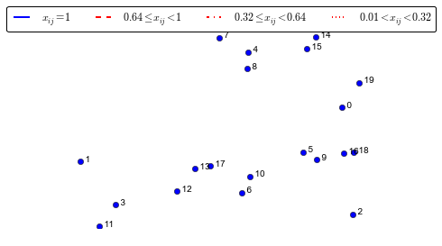

```python
ran_points = Cities(n=20,seed=25)
plot_situation(ran_points)
```

Alternatively, we can read the `dantiz42.dat` instance which represents locations in USA.

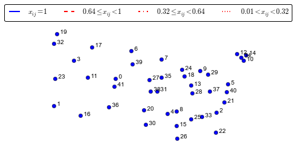

```python
dantzig42 = read_instance("dantzig42.dat")
plot_situation(dantzig42)
```

## Dantzig, Fulkerson and Johnson (DFJ) Formulation

Consider the following formulation of the *symmetric traveling salesman problem* due to Dantzig, Fulkerson and Johnson, 1954 (DFJ) that we have been discussing during the course. Let $V=\{0..n-1\}$ be the set of nodes and $E$ the set of edges. Let $E(S)$ be the set of edges induced by the subset of vertices $S$ and $\delta(v)$ the set of edges in the cut $(v,V\setminus\{v\})$. (We will assume that an edge between two nodes $i$ and $j$ is present in $E$ in the form $ij$ if $j>i$ and $ji$ if $ j < i $.) $$\begin{aligned} \text{(TSPIP)}\quad \min\; & \sum c_{ij} x_{ij} \\ \text{s.t.}\;&\sum_{ij \in \delta(i)} x_{ij}+\sum_{ji \in \delta(i)}x_{ji}=2 \text{ for all } i \in V\\ \label{subtour}&\sum_{ij \in E(S)} x_{ij} \leq |S|-1 \text{ for all } \emptyset \subset S\subset V, 2 \leq |S| \leq n-1\\ &x_{ij} \in \{0,1\} \text{ for all } {ij} \in E\end{aligned}$$

We can generate all subsets of the set of 20 randomly generated cities as follows:

```python
from itertools import chain, combinations
def powerset(iterable):
    "powerset([1,2,3]) --> () (1,) (2,) (3,) (1,2) (1,3) (2,3) (1,2,3)"
    s = list(iterable)
    return chain.from_iterable(combinations(s, r) for r in range(len(s)+1))

subtours = list(powerset(range(len(ran_points))))
# The first element of the list is the empty set and the last element is the full set, hence we remove them.
subtours = subtours[1:(len(subtours)-1)]
```

### Task 1

Implement the DFJ formulation in the model below and solve your random instance:

```python
def solve_tsp(points, subtours=[], VAR_TYPE=GRB.INTEGER, silent=True):
    points=list(points)
    V = range(len(points))
    E = [(i,j) for i in V for j in V if i<j] # complete graph
    E = tuplelist(E)

    m = Model("TSP0")
    if silent:
        m.setParam(GRB.Param.OutputFlag,0)
    m.setParam(GRB.param.Presolve, 0) # no preprocessing
    m.setParam(GRB.param.Method, 0)
    m.setParam(GRB.param.MIPGap,1e-7)



    ######### BEGIN: Write here your model for Task 1
    x = OrderedDict()
    for (i,j) in E:
        x[i,j]=m.addVar(lb=0.0, ub=1.0, obj=distance(points[i],points[j]), vtype=VAR_TYPE, name="x[%d,%d]" % (i,j))

    ## Objective
    m.modelSense = GRB.MINIMIZE

    ## Constraints
    for v in V:
        m.addConstr(quicksum(x[v,i] for v,i in E.select(v,'*')) +
                    quicksum(x[i,v] for i,v in E.select('*',v)) == 2,"flow_balance_%d" % v)

    for S in subtours:
        m.addConstr(quicksum(x[i,j] for i in S for j in S if i<j)<=len(S)-1,"tour_elim_%d" % sum(S))
    ######### END

    m.optimize()
    m.write("tsplp.lp")

    if m.status == GRB.status.OPTIMAL:
        print('Solve TSP: the optimal objective value is %g' % m.objVal)
        m.write("tsplp.sol") # write the solution
        return {(i,j) : x[i,j].x for i,j in x}
    else:
        print "Something wrong in solve_tsplp"
        exit(0)
```

If we try to solve the small instance on 20 cities with this model, ie:

```
solve_tsp(ran_points, subtours)
```

we get out of memory (you can be more lucky but if so try increasing your instance with a few more cities).

```
solve_tsp(ran_points,subtours)

Changed value of parameter Presolve to 0
   Prev: -1  Min: -1  Max: 2  Default: -1
Changed value of parameter Method to 0
   Prev: -1  Min: -1  Max: 4  Default: -1
Changed value of parameter MIPGap to 1e-07
   Prev: 0.0001  Min: 0.0  Max: 1e+100  Default: 0.0001
Optimize a model with 1048594 rows, 190 columns and 49807550 nonzeros
Variable types: 0 continuous, 190 integer (0 binary)
Coefficient statistics:
  Matrix range     [1e+00, 1e+00]
  Objective range  [3e+01, 9e+02]
  Bounds range     [1e+00, 1e+00]
  RHS range        [1e+00, 2e+01]

Explored 0 nodes (0 simplex iterations) in 0.34 seconds
Thread count was 1 (of 8 available processors)

Solution count 0
Pool objective bound 0

Best objective -, best bound -, gap -

---------------------------------------------------------------------------
GurobiError                               Traceback (most recent call last)
<ipython-input-7-8784813f6174> in <module>()
----> 1 solve_tsp(ran_points,subtours)

<ipython-input-6-8bb38fbd53a5> in solve_tsp(points, subtours)
     27     ######### END
     28
---> 29     m.optimize()
     30     m.write("tsplp.lp")
     31

model.pxi in gurobipy.Model.optimize (../../src/python/gurobipy.c:54012)()

GurobiError: Out of memory
```

## A Cutting Plane Approach

The number of subtour elimination constraints in the DFJ formulation can be huge ($2^n$) and even though we can remove half of those due to symmetries, there are still exponentially many. A way to deal with large families of constraints is to introduce them only when needed. This idea is similar to the cutting plane algorithm that we saw in the intro classes. We start by solving the relaxed version of (TSPIP) obtained by removing the integrality constraints and the exponentially many subtour elimination constraints. We dub this relaxation TSPLP$_0$. Let $x^*$ be the optimal solution of TSPLP$_0$.

### Task 2

Implement the new function `solve_tsp(points, subtours=[])` that solves the relaxed version TSPLP$_0$ and solve your random instance with 20 points. Inspect the plot of the solution obtained.

```
tsplp0 = solve_tsp(ran_points, [])
plot_situation(ran_points, tsplp0)
```

Describe what you observe. Are all variables integer? Is the matrix TUM? Why? Is the solution a tour? Is the solution matching your expectations?

Relaxing only the subtour elimination constraints in `solve_tsp` we obtain:

```
Changed value of parameter Presolve to 0
   Prev: -1  Min: -1  Max: 2  Default: -1
Changed value of parameter Method to 0
   Prev: -1  Min: -1  Max: 4  Default: -1
Changed value of parameter MIPGap to 1e-07
   Prev: 0.0001  Min: 0.0  Max: 1e+100  Default: 0.0001
Optimize a model with 20 rows, 190 columns and 380 nonzeros
Variable types: 0 continuous, 190 integer (0 binary)
Coefficient statistics:
  Matrix range     [1e+00, 1e+00]
  Objective range  [3e+01, 9e+02]
  Bounds range     [1e+00, 1e+00]
  RHS range        [2e+00, 2e+00]
Found heuristic solution: objective 7553.48
Variable types: 0 continuous, 190 integer (190 binary)

Root relaxation: objective 2.319977e+03, 48 iterations, 0.00 seconds

    Nodes    |    Current Node    |     Objective Bounds      |     Work
 Expl Unexpl |  Obj  Depth IntInf | Incumbent    BestBd   Gap | It/Node Time

     0     0 2319.97722    0    6 7553.48272 2319.97722  69.3%     -    0s
H    0     0                    2412.4382037 2319.97722  3.83%     -    0s
H    0     0                    2323.4948269 2319.97722  0.15%     -    0s

Explored 0 nodes (48 simplex iterations) in 0.03 seconds
Thread count was 8 (of 8 available processors)

Solution count 3: 2323.49 2412.44 7553.48
Pool objective bound 2323.49

Optimal solution found (tolerance 1.00e-07)
Best objective 2.323494826897e+03, best bound 2.323494826897e+03, gap 0.0000%
Solve TSP: the optimal objective value is 2323.49
```

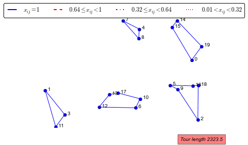

```python
tsplp0 = solve_tsp(ran_points, [], GRB.INTEGER, False)
plot_situation(ran_points, tsplp0)
```

Relaxing also the integrality constraints `vtype=GRB.INTEGER` is more convenient since the solution will be faster:

```python
tsplp0 = solve_tsp(ran_points, [], GRB.CONTINUOUS, False)
plot_situation(ran_points, tsplp0)
```

[output not shown]

```
Changed value of parameter Presolve to 0
   Prev: -1  Min: -1  Max: 2  Default: -1
Changed value of parameter Method to 0
   Prev: -1  Min: -1  Max: 4  Default: -1
Changed value of parameter MIPGap to 1e-07
   Prev: 0.0001  Min: 0.0  Max: 1e+100  Default: 0.0001
Optimize a model with 20 rows, 190 columns and 380 nonzeros
Coefficient statistics:
  Matrix range     [1e+00, 1e+00]
  Objective range  [3e+01, 9e+02]
  Bounds range     [1e+00, 1e+00]
  RHS range        [2e+00, 2e+00]
Iteration    Objective       Primal Inf.    Dual Inf.      Time
       0    2.6172030e+03   0.000000e+00   6.345460e+04      0s
      48    2.3199772e+03   0.000000e+00   0.000000e+00      0s

Solved in 48 iterations and 0.00 seconds
Optimal objective  2.319977221e+03
Solve TSP: the optimal objective value is 2319.98
```

You should pay attention to the two different outputs of gurobi. In particular, in the latter output with continuous variables you find the log of the iterations of the primal simplex, while in the output of the model with interger variables you find the log of the branch and bound process in which the 48 iterations of the LP relaxation at the root is summarized in one single row. In the linear relaxation the variables are not all integer. The matrix is indeed not TUM because although we have only two terms different from zero in each column of the matrix, they are both positive and the graph is not bipartite, hence we are not able to separate the rows in the fashion described by the theorem. The solution is not a tour, since, as expected, there are subtours and fractional variables.

**An alternative directed graph formulation**. Note that if we had used a directed representation of the problem, by introducing for each edge two oriented arcs then we would have had a TUM matrix, although the number of arcs would have been now double. Let $A=\{ij\mid i\in V,j\in V,i\neq j\}$ and let $\delta^+(i)$ and $\delta^-(i)$ the set of arcs, respectively, outgoing and ingoing $i$: $$\begin{aligned} \text{(TSPIP)}\quad \min\; & \sum_{ij \in A} c_{ij} x_{ij} \\ \text{s.t.}\;&\sum_{ij \in \delta^+(i)} x_{ij}=1 \text{ for all } i \in V\\ &\sum_{ji \in \delta^-(i)} x_{ji}=1 \text{ for all } i \in V\\ &\sum_{ij \in A(S)} x_{ij} \leq |S|-1 \text{ for all } \emptyset \subset S\subset V, 2 \leq |S| \leq n-1\\ &x_{ij} \in \{0,1\} \text{ for all } {ij} \in E \end{aligned}$$

```python
def solve_tsp_directed(points, subtours=[], VAR_TYPE=GRB.INTEGER, silent=True):
    points=list(points)
    V = range(len(points))
    A = [(i,j) for i in V for j in V if i!=j] # complete graph
    A = tuplelist(A)

    m = Model("TSP0")
    if silent:
        m.setParam(GRB.Param.OutputFlag,0)
    m.setParam(GRB.param.Presolve, 0) # no preprocessing
    m.setParam(GRB.param.Method, 0)
    m.setParam(GRB.param.MIPGap,1e-7)


    ######### BEGIN: Write here your model for Task 1
    x = OrderedDict()
    for (i,j) in A:
        x[i,j]=m.addVar(lb=0.0, ub=1.0, obj=distance(points[i],points[j]), vtype=VAR_TYPE, name="x[%d,%d]" % (i,j))

    ## Objective
    m.modelSense = GRB.MINIMIZE

    ## Constraints
    for v in V:
        m.addConstr(quicksum(x[i,v] for i,v in A.select('*',v)) == 1,"incoming_flow_balance_%d" % v)
        m.addConstr(quicksum(x[v,i] for v,i in A.select(v,'*')) == 1,"outgoing_flow_balance_%d" % v)

    for S in subtours:
        m.addConstr(quicksum(x[i,j] for i in S for j in S if i!=j)<=len(S)-1,"tour_elim_%d" % sum(S))
    ######### END

    m.optimize()
    m.write("tsplp.lp")

    if m.status == GRB.status.OPTIMAL:
        print('Solve TSP: the optimal objective value is %g' % m.objVal)
        m.write("tsplp.sol") # write the solution
        return {(i,j) : x[i,j].x for i,j in x}
    else:
        print "Something wrong in solve_tsplp"
        exit(0)
```

```
Changed value of parameter Presolve to 0
   Prev: -1  Min: -1  Max: 2  Default: -1
Changed value of parameter Method to 0
   Prev: -1  Min: -1  Max: 4  Default: -1
Changed value of parameter MIPGap to 1e-07
   Prev: 0.0001  Min: 0.0  Max: 1e+100  Default: 0.0001
Optimize a model with 40 rows, 380 columns and 760 nonzeros
Coefficient statistics:
  Matrix range     [1e+00, 1e+00]
  Objective range  [3e+01, 9e+02]
  Bounds range     [1e+00, 1e+00]
  RHS range        [1e+00, 1e+00]
Iteration    Objective       Primal Inf.    Dual Inf.      Time
       0    2.7995373e+03   0.000000e+00   1.406603e+05      0s
      88    1.8443232e+03   0.000000e+00   0.000000e+00      0s

Solved in 88 iterations and 0.00 seconds
Optimal objective  1.844323189e+03
Solve TSP: the optimal objective value is 1844.32
```

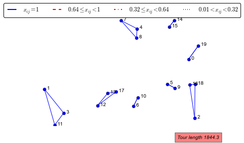

```python
tsplp0 = solve_tsp_directed(ran_points, [], GRB.CONTINUOUS, False)
plot_situation(ran_points, tsplp0)
```

As we see, an integer solution is found without need of a branch and bound (see the output of gurobi). However, a side effect of considering a directed graph formulation is the fact that subtours of lenght 2 are not eliminated and we actually get 4 of them in the case above.

### Task 3

Detect by visual inspection some subtour inequalities to add to TSPLP0. List those subtours in the subtour argument of the function `solve_tsp` and solve the new problem TSPLP$_1$=TSPLP$_0 \cup c$, where $c$ is the constraint added. Report the visualization produced by `plot_situation` on the new solution. Is it a tour? If not iterate this procedure until you cannot find anymore subtours. Show your last solution and comment on it.

#### Solution

```python
tsplp0 = solve_tsp(ran_points, [], GRB.CONTINUOUS)
plot_situation(ran_points, tsplp0)
```

```
Solve TSP: the optimal objective value is 2319.98
```

```
Solve TSP: the optimal objective value is 2709.87
```

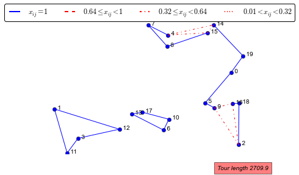

```python
tsplp1 = solve_tsp(ran_points, [[1,3,11], [7,4,8], [14,15,19,0], [12,13,17]], GRB.CONTINUOUS)
plot_situation(ran_points, tsplp1)
```

```python
tsplp1 = solve_tsp(ran_points, [[1,12,3,11],[13,17,10,6],[16,18,2], [1,3,11],
                                [7,4,8], [14,15,19,0], [12,13,17]], GRB.CONTINUOUS)
plot_situation(ran_points, tsplp1)
```

[output not shown]

```
Solve TSP: the optimal objective value is 2755.15
```

We found a tour! The solution is optimal since it satisfies all the constraints of the DFJ formulation. The value of the solution is 2755.15. However, we were lucky: things do not necessarily always end in this way. We could have no subtour constraints unsatisfied but a solution not yet integer. This is for example the case for the instance `dantzig42` as we will see below.

### Task 4

We can automatize the manual process described above. Let $V'=V\setminus\{0\}$ and $E'=E\setminus\{\delta(0)\}$. A set $S\subseteq V'$ that contains a vertex $k$ forms a subtour in $x^*$ if $$\sum_{e=ij \in E'(S)} x_e^* > |S \setminus \{k\} |=|S|-1.$$

We can find the subtour elimination constraint that is most violated by $x^*$ by solving the following *separation problem* for $k=\{1..n-1\}$. Let’s represent the unknown set $S \subseteq V'$ by binary variables $z$ with $z_i=1$ if $i \in S$ then the separation problem for $k=\{1..n-1\}$ is

$$ (SEP) \quad \xi_k=\max \left\{ \sum_{e=ij\in E':i < j} x^*_e z_i z_j - \sum_{i \in V' \setminus \{k\}} z_i : z \in \mathbb{B}^n, z_k=1\right\} $$

If $ \xi_k > 0 $ for some $k$ then the solution $z^*$ of SEP gives a subtour $S$, containing $k$, whose corresponding subtour elimination constraint in TSPIP is violated by $x^*$. We insert this constraint in TSPLP$_0$ and solve the new problem TSPLP$_1$.

Rewrite the (SEP) problem for some $k$ as an integer linear program and report the mathematical model in your answers.

**Solution**

### Task 5

Implement your model in the function `solve_separation(points, x_star, k)` below and solve the **LP relaxation of the (SEP) problem** to separate the optimal solution $x^*$ of TSPLP$_0$.

```python
def solve_separation(points, x_star, k, VAR_TYPE=GRB.CONTINUOUS, silent=True):
    points=list(points)
    V = range(len(points))
    Vprime = range(1,len(points))
    E = [(i,j) for i in V for j in V if i<j]
    Eprime = [(i,j) for i in Vprime for j in Vprime if i<j]
    E = tuplelist(E)
    Eprime = tuplelist(Eprime)

    m = Model("SEP")
    if silent:
        m.setParam(GRB.Param.OutputFlag,0)
    m.setParam(GRB.Param.Presolve, 0)
    m.setParam(GRB.Param.Method, 0)
    m.setParam(GRB.Param.MIPGap,1e-7)


    ######### BEGIN: Write here your model for Task 4
    y={}
    for i,j in Eprime:
        y[i,j]=m.addVar(lb=0.0,ub=1.0,obj=x_star[i,j],vtype=VAR_TYPE,name="y[%d,%d]" % (i,j))
    z={}
    for v in Vprime:
        if v!=k:
            z[v]=m.addVar(lb=0.0,ub=1.0,obj=-1.0,vtype=VAR_TYPE,name="z[%d]" % (v))
        else:
            z[v]=m.addVar(lb=0.0,ub=1.0,obj=0.0,vtype=VAR_TYPE,name="z[%d]" % (v))

    # Objective
    m.modelSense = GRB.MAXIMIZE

    # Constraints
    for i,j in Eprime:
        m.addConstr(y[i,j]<=z[i])
        m.addConstr(y[i,j]<=z[j])
        m.addConstr(y[i,j]>=z[i]+z[j]-1)

    m.addConstr(z[k]==1)

    ######### END
    m.optimize()
    m.write("sep.lp")

    if m.status == GRB.status.OPTIMAL:
        m.write("sep.sol") # write the solution
        subtour = filter(lambda i: z[i].x>=0.99,z)
        return m.objVal, subtour
    else:
        print "Something wrong in solve_tsplp"
        exit(0)
```

Try your implementation of `solve_separation` on your previous TSPLP$_0$ solution. Do you get the expected answer?

```python
tsplp0 = solve_tsp(ran_points, [], GRB.CONTINUOUS)
plot_situation(ran_points, tsplp0)
S_star = solve_separation(ran_points, tsplp0, 12, VAR_TYPE=GRB.CONTINUOUS)
print S_star
```

```
Solve TSP: the optimal objective value is 2319.98
```

```
(1.0, [2, 5, 6, 9, 10, 12, 13, 16, 17, 18])
```

This means that by solving for the vertex k=12 we find the set S that contains 12 and violates the most the subtour eliimination constraint. We should now solve for all k.

### Task 6

The following procedure `cutting_plane_alg` implements the cutting plane algorithm that uses your implementation of `solve_tsp` and `solve_separation`. Finish the implementation of the function. That is: add the condition for the presence of violated inequalities.

```python
def cutting_plane_alg(points, silent=True):
    Vprime = range(1,len(points))
    subtours = []
    found = True
    while found:
        lpsol = solve_tsp(points,subtours, GRB.CONTINUOUS)
        if not silent:
            plot_situation(points, lpsol)
        found = False
        tmp_subtours = []
        best_val = float('-inf')
        for k in Vprime:
            value, subtour = solve_separation(points,lpsol,k,GRB.CONTINUOUS)
            if not silent:
                print('Separation problem solved for k=%d, solution value %g' % (k,value))
            best_val = value if value > best_val else best_val
            ######### BEGIN: write here the condition. Include a tollerance
            if value > 0.0001:
            ######### END
                found = True
                tmp_subtours += [subtour]
        subtours += tmp_subtours
        if not silent:
            print '*'*60
            print "Subtours found: ",tmp_subtours,"\nwith best value : ",best_val
            print '*'*60
    plot_situation(points, lpsol)
```

Run the cutting plane algorithm thus implemented until termination. Report the plot of the last solution found by solving the TSPLP$_n$ problem, where $n$ is the number of iterations in which violated inequalities were found. Is the solution optimal?

```
Solve TSP: the optimal objective value is 2319.98
```

```
Separation problem solved for k=1, solution value 1
Separation problem solved for k=2, solution value 1
Separation problem solved for k=3, solution value 1
Separation problem solved for k=4, solution value 1
Separation problem solved for k=5, solution value 1
Separation problem solved for k=6, solution value 1
Separation problem solved for k=7, solution value 1
Separation problem solved for k=8, solution value 1
Separation problem solved for k=9, solution value 1
Separation problem solved for k=10, solution value 1
Separation problem solved for k=11, solution value 1
Separation problem solved for k=12, solution value 1
Separation problem solved for k=13, solution value 1
Separation problem solved for k=14, solution value -0
Separation problem solved for k=15, solution value -0
Separation problem solved for k=16, solution value 1
Separation problem solved for k=17, solution value 1
Separation problem solved for k=18, solution value 1
Separation problem solved for k=19, solution value -0
Subtours found:  [[1, 3, 11], [2, 5, 6, 9, 10, 12, 13, 16, 17, 18], [1, 3, 11], [4, 7, 8], [2, 5, 6, 9, 10, 12, 13, 16, 17, 18], [2, 5, 6, 9, 10, 12, 13, 16, 17, 18], [4, 7, 8], [4, 7, 8], [2, 5, 6, 9, 10, 12, 13, 16, 17, 18], [2, 5, 6, 9, 10, 12, 13, 16, 17, 18], [1, 3, 11], [2, 5, 6, 9, 10, 12, 13…
with best value :  1.0
Solve TSP: the optimal objective value is 2709.87
```

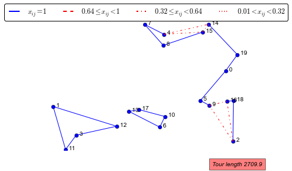

```
Separation problem solved for k=1, solution value 1
Separation problem solved for k=2, solution value 0.5
Separation problem solved for k=3, solution value 1
Separation problem solved for k=4, solution value 0.5
Separation problem solved for k=5, solution value 0.5
Separation problem solved for k=6, solution value 1
Separation problem solved for k=7, solution value 0.5
Separation problem solved for k=8, solution value 0.5
Separation problem solved for k=9, solution value 0.5
Separation problem solved for k=10, solution value 1
Separation problem solved for k=11, solution value 1
Separation problem solved for k=12, solution value 1
Separation problem solved for k=13, solution value 1
Separation problem solved for k=14, solution value 0.5
Separation problem solved for k=15, solution value 0.5
Separation problem solved for k=16, solution value 0.5
Separation problem solved for k=17, solution value 1
Separation problem solved for k=18, solution value 0.5
Separation problem solved for k=19, solution value 0.5
Subtours found:  [[1, 3, 11, 12], [2, 16, 18], [1, 3, 11, 12], [4, 7, 8, 15], [2, 5, 9, 16, 18], [6, 10, 13, 17], [4, 7, 8, 14, 15], [4, 7, 8, 14, 15], [2, 9, 16, 18], [6, 10, 13, 17], [1, 3, 11, 12], [1, 3, 11, 12], [6, 10, 13, 17], [4, 7, 8, 14, 15], [4, 7, 8, 15], [2, 16, 18], [6, 10, 13, 17], [2…
with best value :  1.0
Solve TSP: the optimal objective value is 2755.15
```

```
Separation problem solved for k=1, solution value -0
Separation problem solved for k=2, solution value -0
Separation problem solved for k=3, solution value -0
Separation problem solved for k=4, solution value -0
Separation problem solved for k=5, solution value -0
Separation problem solved for k=6, solution value -0
Separation problem solved for k=7, solution value -0
Separation problem solved for k=8, solution value -0
Separation problem solved for k=9, solution value -0
Separation problem solved for k=10, solution value -0
Separation problem solved for k=11, solution value -0
Separation problem solved for k=12, solution value -0
Separation problem solved for k=13, solution value -0
Separation problem solved for k=14, solution value -0
Separation problem solved for k=15, solution value -0
Separation problem solved for k=16, solution value -0
Separation problem solved for k=17, solution value -0
Separation problem solved for k=18, solution value -0
Separation problem solved for k=19, solution value -0
Subtours found:  []
with best value :  -0.0
```

```python
cutting_plane_alg(ran_points, False)
```

We find the same optimal solution as eariler.

### Task 7 (Optional)

Reflecting upon the process implemented you may wonder whether we are gaining anything in efficiency. After all we circumvented having to solve the original integer programming formulation of the TSP by having to solve many separation problems, which are in principle all integer programming problems and hence possibly hard to solve. It turns out that the SEP problems are actually solvable efficiently. In task 5, you were given the tip to implement the LP relaxation of the SEP problem. Why are the solutions to SEP always integer? It turns out that the SEP corresponds to one problem treated during the course. Which one? In efficient implementations the SEP problem is solved by specialized algorithms for this problem. [Hint: It may help to consider the other way to formulate subtour elimination constraints, that is, cut-set constraints.]

Solutions to the LP relaxation of (SEP) are always integer because the matrix is TUM. (Since $x^*\geq 0$ then we wish $y_e$ as large as possible. Thus by - $y_e=\min(z_i,z_j)$ and $\min(z_i,z_j)\geq z_i+z_j-1$ is always satisfied and can be dropped. We are left with a matrix with a block that contains only two consecutive ones on each column (for the variables $y$) concatenated with two identity matrices (for the variables $z$). Such a matrix can be shown to be TUM (consecutive ones can be rearranged and a partition satisfying the sufficiency conditions found + concatation with identity matrices preserve TUM properties).

The problem to solve is the *global min cut problem*, which can be solved solving $n-1$ min cut problems. The MIP formulation of the min cut problem is the dual of the dual the maximum flow problem. Hence for $k=\{2..n\}$ and an arbitrarily chosen $t$: $$\begin{aligned} \min\;& \alpha_{ij}x^*_{ij}\\ &u_i-u_j+\alpha_{ij}\geq 0 \quad \forall ij \in E'\\ &u_k-u_t\geq 1\\ &u_k=1\\ &u_i\in \{0,1\}\quad \forall i \in V'\\ &\alpha_{ij}\geq 0 \quad \forall ij \in E'\\\end{aligned}$$

### Task 8 (Optional)

In task 6, you run the cutting plane algorithm until no cutting plane can be found anymore. Is this cutting plane algorithm enough to solve your instance to optimality? What about the general case on any arbitrary instance? Write your considerations and conclusions. [Hint: try the whole procedure on the instances `dantzig42.dat` and `dantzig42.dat` to see what happens in the general case. Report the final plots on these instance.]

As argued before, the solution found to the random instance is optimal.

```
Solve TSP: the optimal objective value is 626.012
Solve TSP: the optimal objective value is 665.93
Solve TSP: the optimal objective value is 673.221
Solve TSP: the optimal objective value is 676.786
Solve TSP: the optimal objective value is 679.116
```

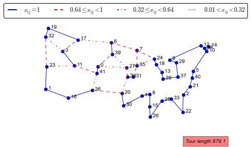

```python
cutting_plane_alg(dantzig42,True)
```

### Task 9

Provide the length of the optimal tour of your problem on 20 nodes.

See above.

### Task 10 (Optional)

Implement the Miller, Tucker and Zemlin (MTZ) formulation from Ex. 7 Sheet 7. Compare the results of the DFJ (that is the name of our previous TSP formulation from the authors Dantzig, Fulkerson, Johnson) and MTZ formulations first on your instance on 20 nodes and then on the instances `berlin52.dat` and `dantzig42`. In both formulations keep the integrality constraints of the main variables so that an optimal solution can be found. Comment the results in your answers: which is the fastest formulation to solve the problem? How many branch and bound nodes are needed in the MTZ formulation to find the optimal solution?

Compare then the results on the instance `berlin52.dat`. Comment the results in your answers: can the MTZ solve the problem? Which of the two formulations provides the best LP relaxation?

Compare the DFJ and MTZ formulations on the basis of the quality of their linear relaxations on the instance `dantzig42`.

Already an instance on 127 vertices is challenging for our implementation. Try your cutting plane procedure on the instance `bier127.dat`, which asks to find the shortest tour among the 127 biergardens in Augsburg, Bavaria. You will have to comment the line for plotting at each iteration, since it is inefficient. Moreover it might be convenient not to wait for all $k$s to be evaluated but to insert a cut as soon as one is found.

Experiment ideas to solve the instance. For example, try combining the cutting plane procedure with integrality constraints in the DFJ formulation or combine the two formulations DFJ and MTZ.

The following formulation (C. E. Miller, A. W. Tucker, and R. A. Zemlin, “Integer programming formulations and traveling salesman problems,” J. ACM, 7 (1960), pp. 326–329) which also eliminates subtours has only a polynomial number of constraints. Let $x_{ij}$ be the variables on the edges with the same meaning as for undirected graphs described above and let $u_{i}$, $i=0,1,\ldots,n-1$ be the number of cities visited already when we arrive at city $i$. $$\begin{aligned} \min & \sum_{(ij) \in A} c_{ij} x_{ij}\\ &\sum_{i:i\neq j} x_{ij}=1 & \forall j=0,\ldots,n-1 \\ &\sum_{j:i\neq j} x_{ij}=1 &\forall i=0,\ldots,n-1 \\ &u_i - u_j + n x_{ij} \leq n - 1, & \forall i, j = 1,2,\ldots, n-1, i\neq j\\ &x_{ij}\in \mathbb{B} &\forall i,j,i\neq j\\ &u_i\in \mathbb{R} & \forall i = 1,\ldots,n-1 \end{aligned}$$

Note that the third constraint can be equivalently written as: $$u_i +1 \leq u_j + n (1-x_{ij}), \qquad i, j = 1, 2,\ldots, n-1, i\neq j $$

Let's fix a vertex, say $0$, to be the home base and for each other vertex $i$ let $u_i$ be an arbitrary real number. The $u_i$ variables play a role similar to node potentials in a network and the inequalities involving them serve to eliminate tours that do not begin and end at city $0$ and tours that visit more than $n-1$ cities. Consider a feasible solution to the TSP: it can be expressed as a permutation of cities, $\pi=(\pi_1=0,\pi_2,\ldots\pi_n,\pi_1=0)$. Hence $x_{\pi_1,\pi_2}=1$. Unless $\pi_2=0$ then there exists $\pi_3$ such that $x_{\pi_2\pi_3}=1$. We proceed in this way until some $\pi_i=0$, which if the solution is feasible happens only at the end of the permutation. The constraint forces $u_{\pi_j}\geq u_{\pi_i}+1$ when $x_{\pi_i,\pi_j}=1$, except when $\pi_{i+1}=0$. Hence an assignment of $\vec u$ can be found when the solution is feasible. On the contrary if there were subtours or a node was visited more than once, then an assignment for the variables $u_i$ that satisfies $u_{\pi_j}\geq u_{\pi_i}+1$ when $x_{\pi_i,\pi_j}=1$ could be found (the constraint would be violated where the subtour closes).

**To be continued**